# Understanding Agent toolings

Maurice Dalton

DISSC / Tobin Center

## Goals for today

1. Understand how Agents use tools
2. Understand how you can create custom tools for agents
3. Provide enough information so you can understand what third party tools are doing
4. Provide a working example

## Motivations

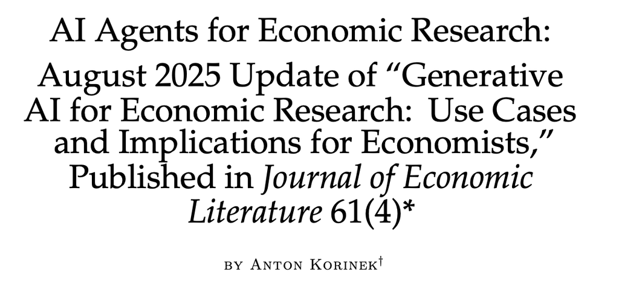

Source: [Korinek (2025)](https://www.aeaweb.org/content/file?id=23290)

## 📈 Towards Agentic chatbots

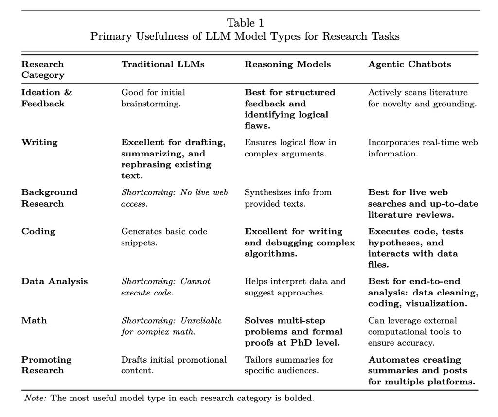

Source: [Korinek (2025)](https://www.aeaweb.org/content/file?id=23290)

## 🤖 Demystifying AI Agents

🔍 What are these new tools?

AI Agents are mostly autonomous systems built on LLMs by giving them access to tools that can:

- 🎯 Manage context, e.g. using memory to keep track of previous steps
- 📝 Create detailed plans
- 🛠️ Use various tools (e.g. web search, code execution, data analysis, write reports) to decide to add context
- 🔄 Execute multi-step tasks
- Orchestrate tasks between specialized agents

## 👨‍💻 What does using an Agentic Chatbot look like?

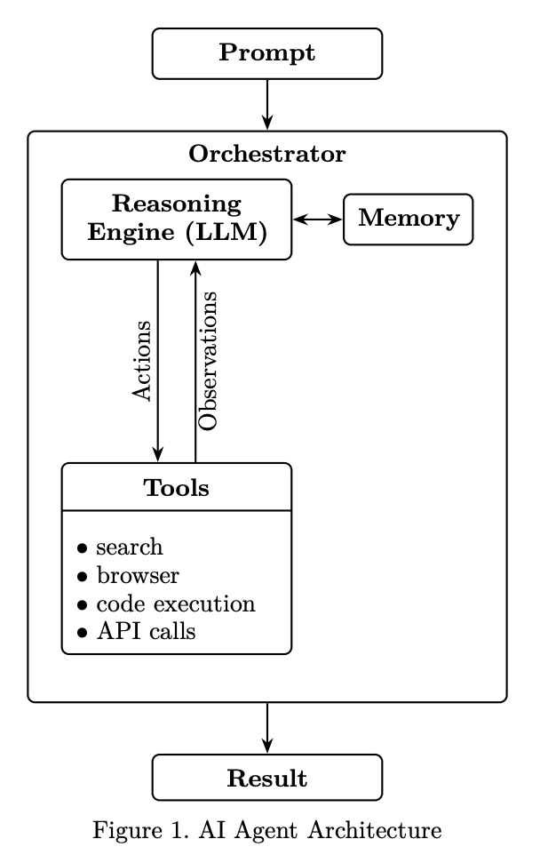

Source: [Korinek (2025)](https://www.aeaweb.org/content/file?id=23290)

## What are tools in the Agent context?

- Model **Context** Protocal (MCP) were developed by anthropic to provide additional context to the LLM
- Expose additional information for the LLM to use
- LLMs discover what tools are available and decide how to use them
  - Tools should focus on high-level capability that aligns with a user’s intent, rather then a thin wrapper for an API
  - The metadata associated with each tool—its name, title, description, and inputSchema—forms a “semantic contract” which impact how the LLM uses the tool
- https://modelcontextprotocol.io/docs/getting-started/intro the doc site is an excellent place to start and much of the material is pulled from this source

## MCP: Architecture for AI Agents

MCP are made up three parts

1. MCP Host, this is the interface; e.g. could be a chat interface or code
2. MCP client: they interact between the LLM and the tools.
3. MCP server: Tool provides actions and descriptions of capabilities

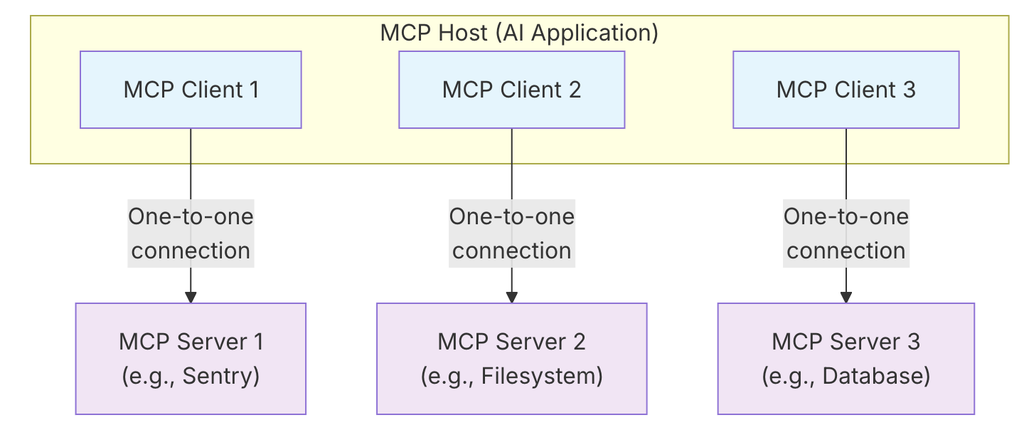

Source: [MCP](https://github.com/modelcontextprotocol/modelcontextprotocol)

## Tools calling flow

When you submit a query:

1. The client gets the list of available tools from the server

2. Your query is sent to the LLM, lets say Claude, along with tool descriptions

3. Claude decides which tools (if any) to use

4. The client executes any requested tool calls through the server

5. Results are sent back to Claude

6. Claude provides a natural language response

7. The response is displayed to you

Source: [MCP](https://github.com/modelcontextprotocol/modelcontextprotocol)

## MCP server

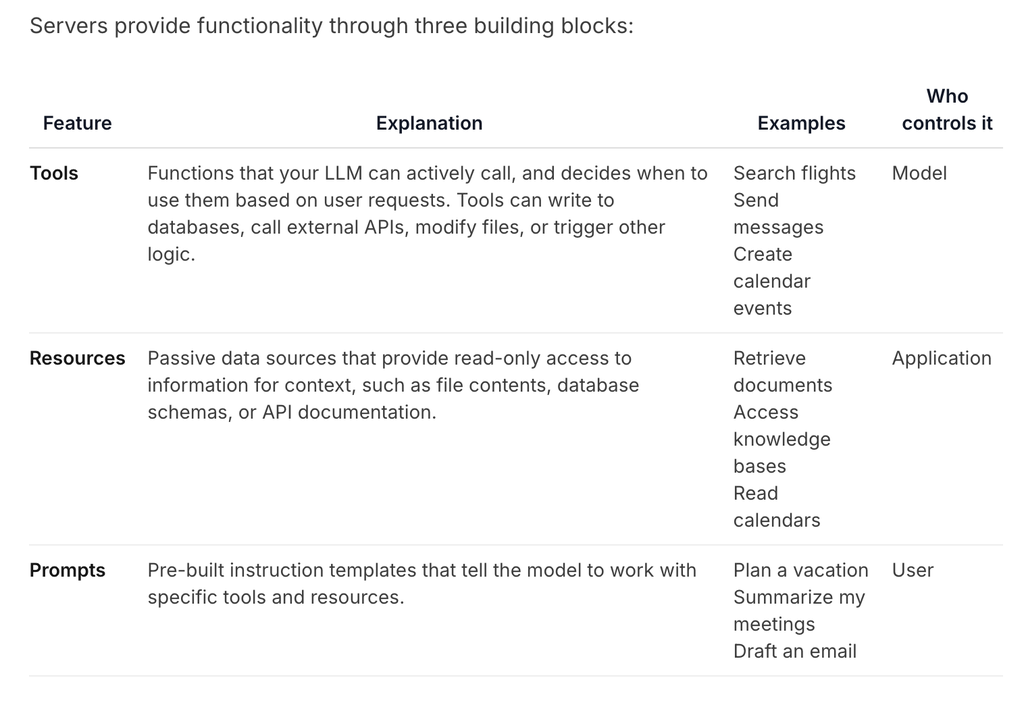

Source: [MCP](https://github.com/modelcontextprotocol/modelcontextprotocol)

## Pophive example, chatting with your data

[figure not shown]

- Pophive (https://www.pophive.org/ ) is a website which aggregates real time data and provides some visualization
- Exploring adding chatbot to allow bespoke data exploration.
- Lots of unknowns for us
  - Where do we host server?
  - How do we scale appropriately while protecting ourselves from cost?
  - Pay per token per user - has the potential to be quite expensive
- For today, we will implement a local MCP server that leans on Claude Desktop and provide `tools` and `resources`,eg the data

## Pophive example architecture

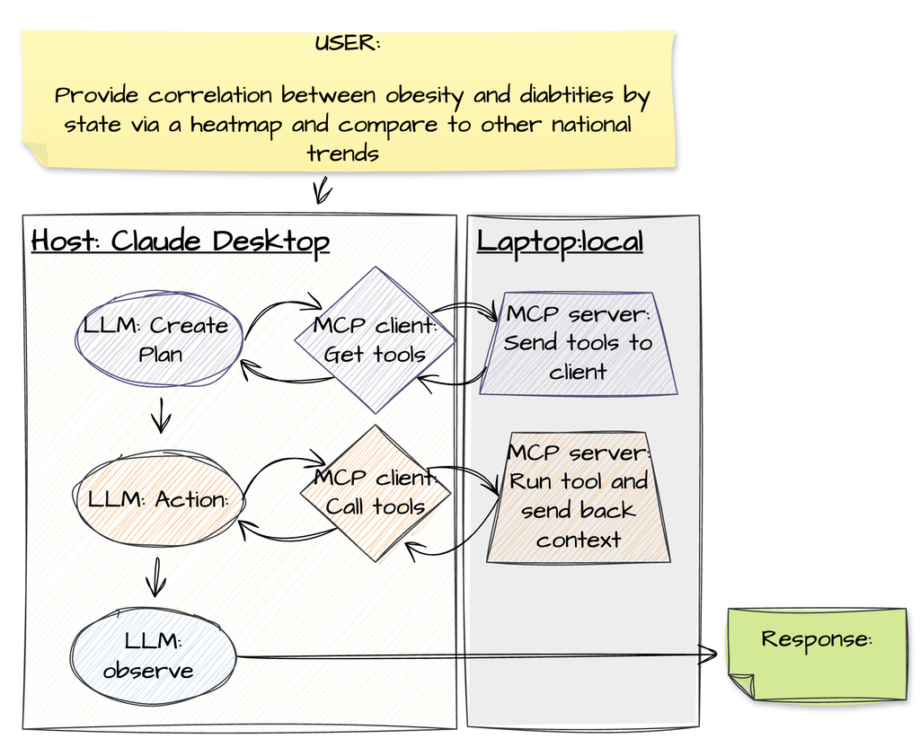

## Creating a local MCP server

- While the ultimate goal is to explore setting an agentic chatbot on a website, we will build a local instance to show how it works
- Will rely on the MCP SDK python library - https://github.com/modelcontextprotocol/python-sdk

## Initialize MCP server

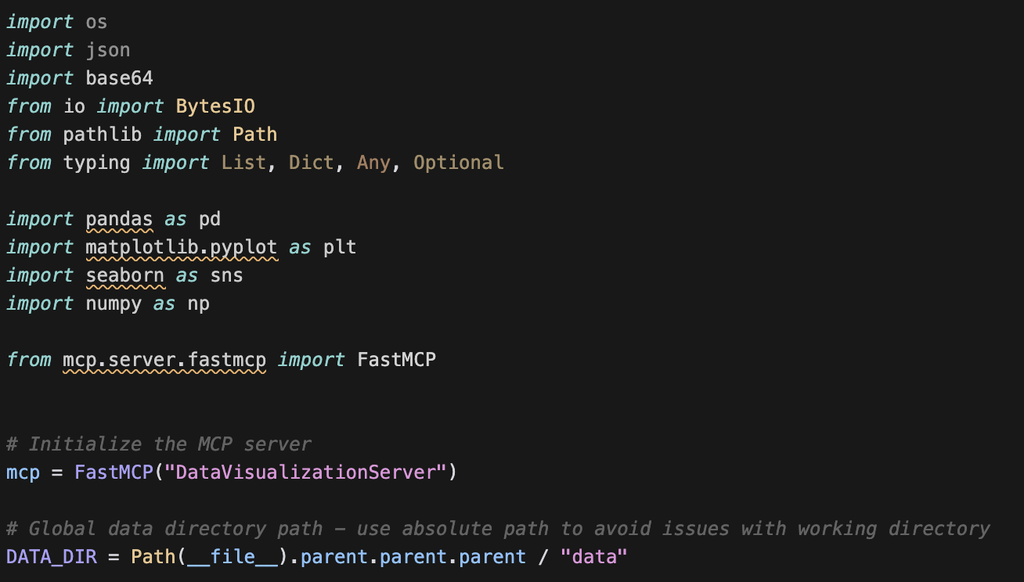

## Initializing tools

- Next you create function with the `@MCP.tool()` decorator
- The name of the tool and the description are used by the LLM to decide how to use the tool
- Note that the server has access to the data found by DATA_DIR, you could have other connections to data here

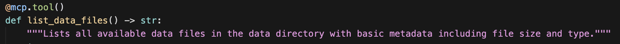

## Tooling logic

- logic looks like a regular python function with context sent back to llm via return statement

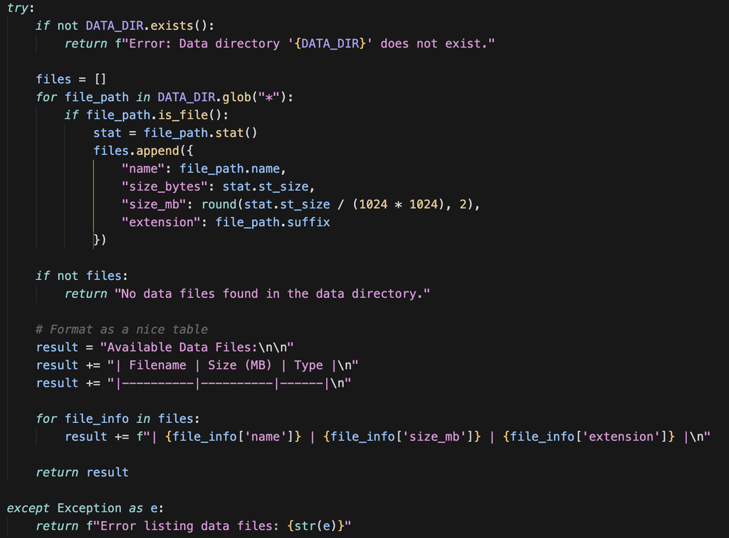

## Tools

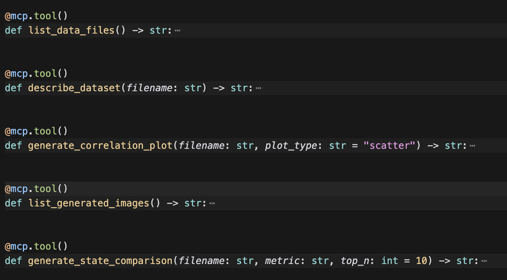

## Everything the MCP server returns consumes tokens

- returning a native figure was using up all my tokens
- save to path instead

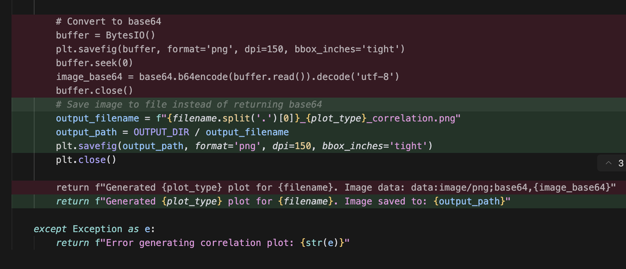

## Lastly, give the host access to the tools

Since this example uses Claude Desktop

1. update the `~/Library/Application Support/Claude/claude_desktop_config.json` file with the following
2. This gives claude access to a new tool

```json
{
  "mcpServers": {
    "data-visualization": {
      "command": "$HOME/git-pub/dissc-agent-tooling/tasks/data-visualization-mcp/venv/bin/python",
      "args": [
        "$HOME/git-pub/dissc-agent-tooling/tasks/data-visualization-mcp/data_viz_server.py"
      ],
      "cwd": "$HOME/git-pub/dissc-agent-tooling/tasks/data-visualization-mcp",
      "env": {
        "DATA_DIR": "$HOME/git-pub/dissc-agent-tooling/data",
        "OUTPUT_DIR": "$HOME/git-pub/dissc-agent-tooling/output/images"
      }
    }
  }
}
```

## MCP for a wider audience

- Worth mentioning that MCP servers can be hosted
- Additional security and cost need to be considered

## Towards modular agents

- Developing tools for an LLM to use is the first step in developing modular agents
- Encourage people to think about breaking down tasks into smaller components so both tools and agents can be reused
- [Agent2Agent communication](https://developers.googleblog.com/en/a2a-a-new-era-of-agent-interoperability/) is one way to achieve this, in that it allows you to abstract to the agent level allowing agent to discover what each agent can do